# Hands-on series: Jupyter Notebook

## Fabien Mathieu

# They speak of Jupyter

- *There's this new thing called NoteBooks, I think it's the future!*, Laurent Viennot
- *NoteBooks are awesome!*, Rémy Leone
- *I have a dream that one application will rise up*, Marc-Olivier Buob
- *You moron should try NoteBooks*, Thomas Bonald

# It's a bird? It's a plane?

## What is a Jupyter Notebook?

# Jupyter NoteBook

- A json file that stores *cells*
- A web server to interpret
- A kernel to execute
- Javascript to display in your favorite browser

# Installation

- Install Anaconda your favorite Python distribution
- Type **jupyter notebook** in a terminal
- Have fun

Optional (recommanded): MiktexLaTeX, nbextensions, Rise, ImageMagick, IJulia your favorite language

# Cells

A NoteBook is made of cells. Three types of cell exist:

- *code cells* for programming
- *markdown cells* for text/maths
- *raw cells* for dirty tricks

# Code cells

```python
x = 6*7
print("The answer is "+str(x))
```

```
The answer is 42
```

All cells share the same kernel

```python
print("The answer is still "+str(x))
```

```
The answer is still 42
```

# Markdown cells: Heading

## This is a subtitle!

### Sub-subtitle

#### And

##### So

###### On

# Markdown cells: Format

- Items are simple to write
  1. *Italic*, **bold**,
  2. **something *mixed***
  3. strike

> A quote

# Markdown cells: Maths

You can use $\LaTeX$ if you want: $$\sum_{n=1}^\infty \frac{n^{-2}}{\left(\frac{13^2+\sqrt{10^3+3^2}+\sqrt{6^2+2\times5^2+2\times13^2\sqrt{10^3+3^2}}}{2^{2}42}\right)} \neq 42$$

# Markdown cells: HTML Markups

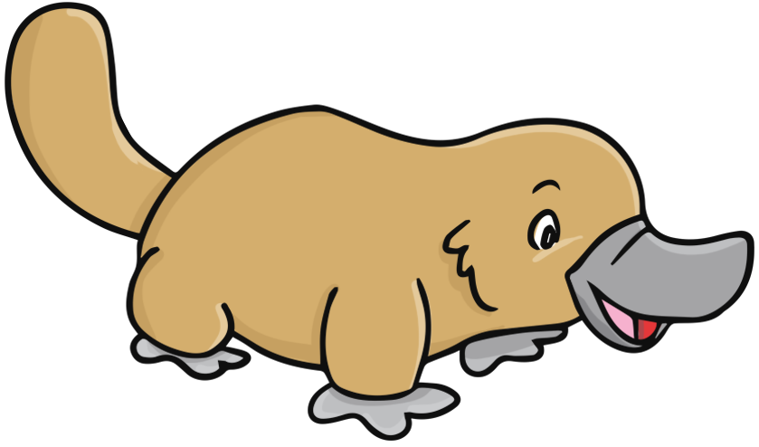

An example with an image on the right of the picture with a markdown cell.

# It's A Kind Of Magic

- *magic commands* change the way a code cell is evaluated
  - single % affects one line
  - double %% affect the whole cell

# Pylab Magic

**%pylab inline** integrate numpy and matplotlib in your notebook.

```python
%pylab inline
```

Then, plot as you like!

# Pylab Magic

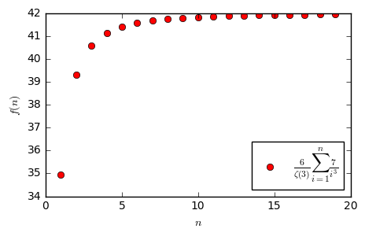

```python
from scipy.special import zeta
x = range(1,20); figure(figsize = (5,3)); plot(x,6/zeta(3,1)*cumsum([7*k**(-3) for k in x]), 'ro',
label = '$\\frac{6}{\\zeta(3)}\\sum_{i = 1}^n \\frac{7}{i^3}$')
xlabel('$n$'); ylabel('$f(n)$'); legend(loc = 4, numpoints = 1); show()
```

# Julia Magic

```python
%%julia
begin
    result = 0
    for i = 3:9
        result += i
    end
    println("Julia says the result is $result !")
end
```

```
Julia says the result is 42 !
```

# HTML Magic

Sometimes, you need something that markup will not accept.

[video not shown]

# Tikz Magic

```python
%load_ext tikzmagic
```

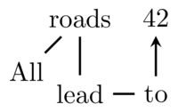

```python
%%tikz --size 200,200
\node (a) {All}; \node[above right of = a] (r) {roads};
\node[below of = r] (l) {lead}; \node[right of = l] (t) {to};
\node[above of = t] (42) {42};
\draw[->,>=stealth, thick] (a) -- (r) -- (l) -- (t) -- (42);
```

# NBExtensions

## A set of time saving / fancy plugins

# Hide Code

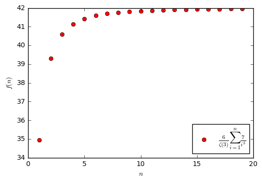

# Execute time

```python
n = 1000000
a = 0
for i in range(n):
    a += 84*random.rand()
print("Estimation of the answer: "+str(a/n))
```

```
Estimation of the answer: 42.02495324649931
```

```python
n = 1000000
a = 84*sum(random.rand(n))
print("Estimation of the answer: "+str(a/n))
```

```
Estimation of the answer: 42.007087753
```

# Spell Checker

No grammar correction, but a basic spelling checker.

Forty-two

# Many other extensions

- Scratchboard
- Comment-Uncomment
- Table of Content
- Just try!

# Other tricks

- Remote access
  - only localhost connexion are allowed
  - **ssh -L** works like a charm!
- Other Kernels (Julia!)

# Presentation with Jupyter

## Rise and Shine

# How does that work?

- **reveal.js**, Keynote for HTML
- Three main modes discovered:
  - RISE
  - HTML
    - CDN reveal.js
    - Local reveal.js

# Rise mode

- Pros
  - Direct from NoteBook
  - Interactive!
- Cons
  - No speaker view
  - Cannot export directly

# HTML mode (CDN)

- Pros
  - One standalone single file
- Cons
  - Static
  - No speaker view
  - Complex export

[Example](https://www.lincs.fr/wp-content/uploads/2013/01/S4-Small-Worlds.prezi_.html#/)

# HTML mode (Local)

- Pros
  - Speaker view!
- Cons
  - Static
  - Must have local **reveal.js**
  - Complex export

[Example (will not work on a remote export)](http://localhost:8888/files/notebook-tutorial.prezi.html)

# Concluding remarks

# Teaching without NoteBooks

- you give students a course (PDF/PPT), a subject (PDF), possibly some code
- you receive copies (Paper/PDF/DOCX/TXT), possibly some code

# Teaching with NoteBooks

- You give students
  - NoteBook presentations
  - NoteBook subjects
- Students return NoteBooks subjects with their answers

# Research without NoteBooks

- Pre-Writing
  - Early code (Spyder/Atom/Matlab)
  - Early maths (paper/whiteboard/tex)
  - Many formats slow down bandwidth
- Writing
  - LaTeX
  - MOAS
- Post-Writing : Beamer/PPT

# Research with NoteBooks

- Use a NoteBook, export to .tex when necessary

# Is Jupyter the new Emacs/NDN?

- Pros:
  - Easy to learn
  - One format to bind them all
- Cons:
  - Hard to master
  - Still under heavy development

# And now?

- This presentation and a more detailed guide should be on the Wiki
- Don't hesitate to contribute
  - Rise with speaker view and one-button export?
  - Fine tuning of cell positioning